# VIS Assignment 1 - Liu

Summer Liu

9/4/2020

```r
library(tidycensus)
library(tidyverse)
```

```r
library(ggplot2)
library(viridis)
library(ggalt)
library(ggthemes)
library(dplyr)
```

#Assignment 1 (09-07-2020)

1. Ability to speak English (ENG) (categorical)
2. Sex (SEX) (categorical)
3. Total person’s income (PINCP) (continuous)
4. Usual hours worked per week past 12 months (WKHP)(continuous)
5. Year of entry (YOEP) (continuous)
6. Age (AGEP) (continuous)

```r
person_vars_2018 <- pums_variables %>%
  distinct(year, survey, var_code,
           var_label, data_type, level) %>%
  filter(level == "person", year == 2018, survey == "acs1")
```

#Data Load

```r
area_vars_2018 <- load_variables(2018, "acs1")
```

#Plot 1 ##There are a lot of overlaying of the spots/ bubbles here, so I don’t think the data is representated very clearly. I am interested to explore how to represent a large sample of data.

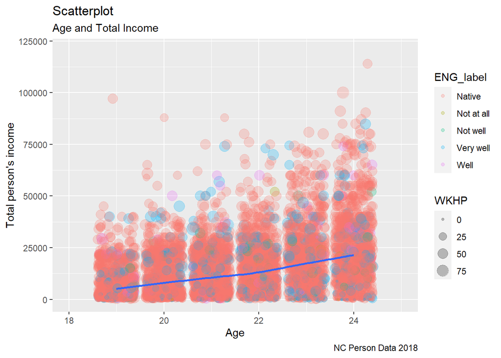

```r
ggplot(person_data, aes(x=AGEP, y=PINCP)) +
  geom_point(aes(col=ENG_label, size=WKHP),alpha=0.25,
             position = "jitter")+
  geom_smooth(method = "loess", se=F) +
  xlim(c(18, 25)) +
  ylim(c(0, 120000)) +
  labs(subtitle="Age and Total Income",
       y="Total person's income",
       x="Age",
       title="Scatterplot",
       caption="NC Person Data 2018")
```

#Plot 2

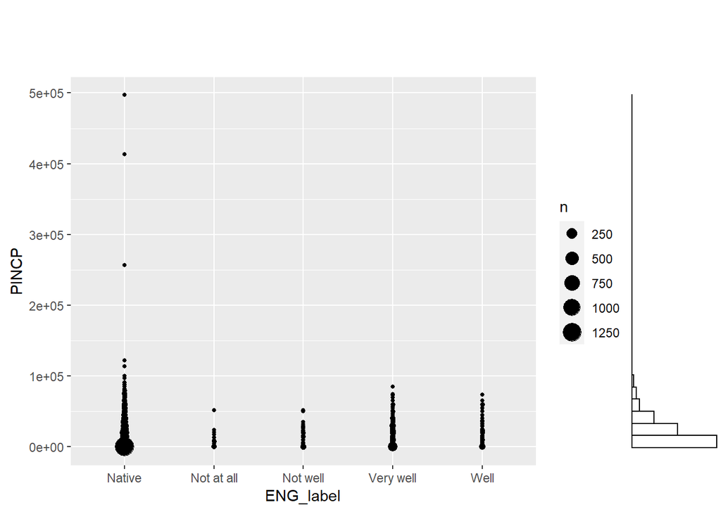

```r
library(ggExtra)
data(person_data, package = "ggplot2")
theme_classic()
g <- ggplot(person_data, aes(ENG_label, PINCP)) +
  geom_count() +
  geom_smooth(method="lm", se=F)

ggMarginal(g, type = "histogram", fill="transparent")
```

```r
Y <- (10 ^(1:10))
format(Y, scientific = FALSE)
```

#Plot 3

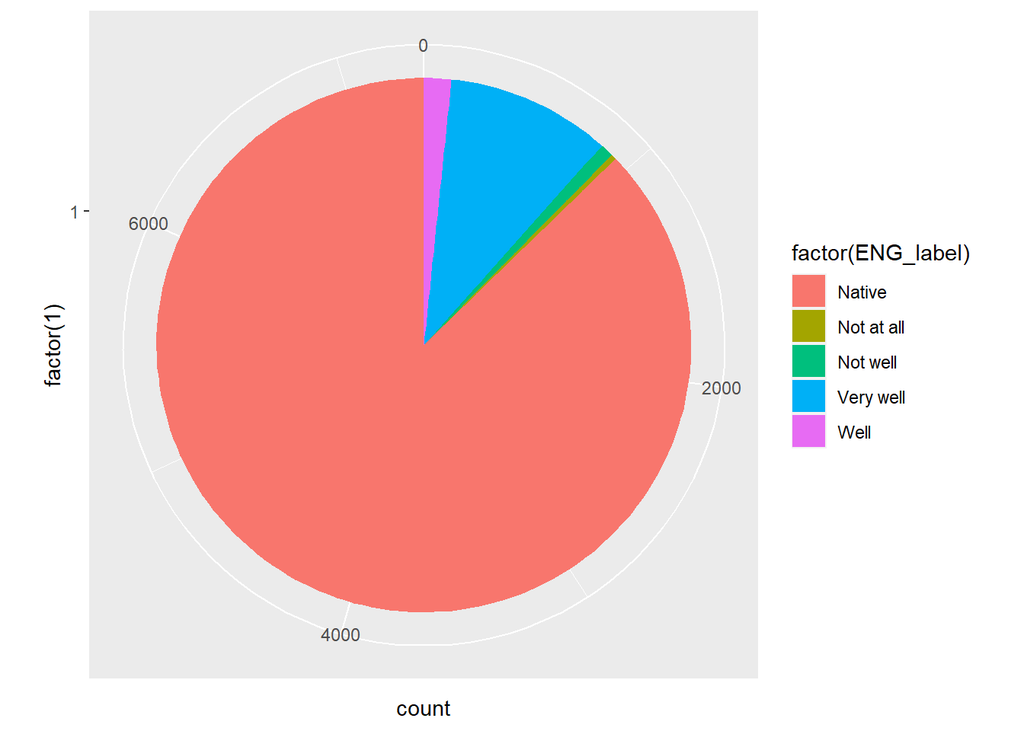

```r
coord_polar(theta = "x", start = 0, direction = 1, clip = "on")
pie <- ggplot(person_data,aes(x = factor(1), fill = factor(ENG_label))) +
  geom_bar(width = 1)
pie + coord_polar(theta = "y")
```

#Plot 4 ##I like how this one shows that if you speak English very well, or if you are a Native, the patterns are very similar, it basically slow transition to the other pattern. I think it shows the strong correlation here.

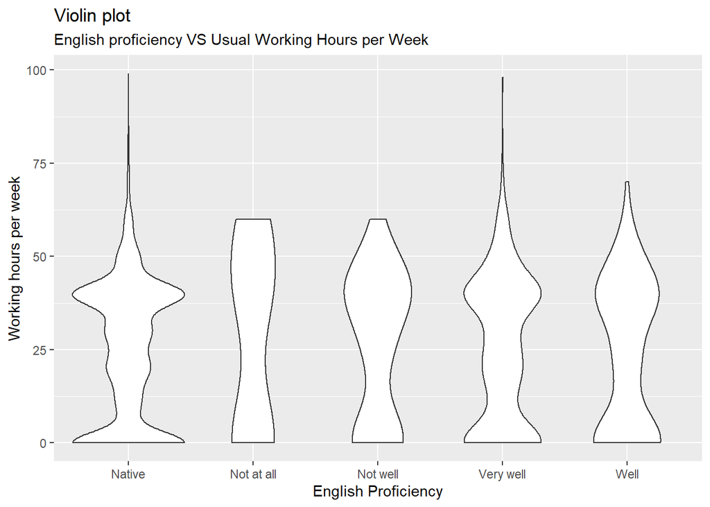

```r
df <- ggplot(person_data,aes(ENG_label, WKHP))
df + geom_violin() +
labs(title="Violin plot",
       subtitle="English proficiency VS Usual Working Hours per Week",
       x="English Proficiency",
       y="Working hours per week")
```

#Plot 5

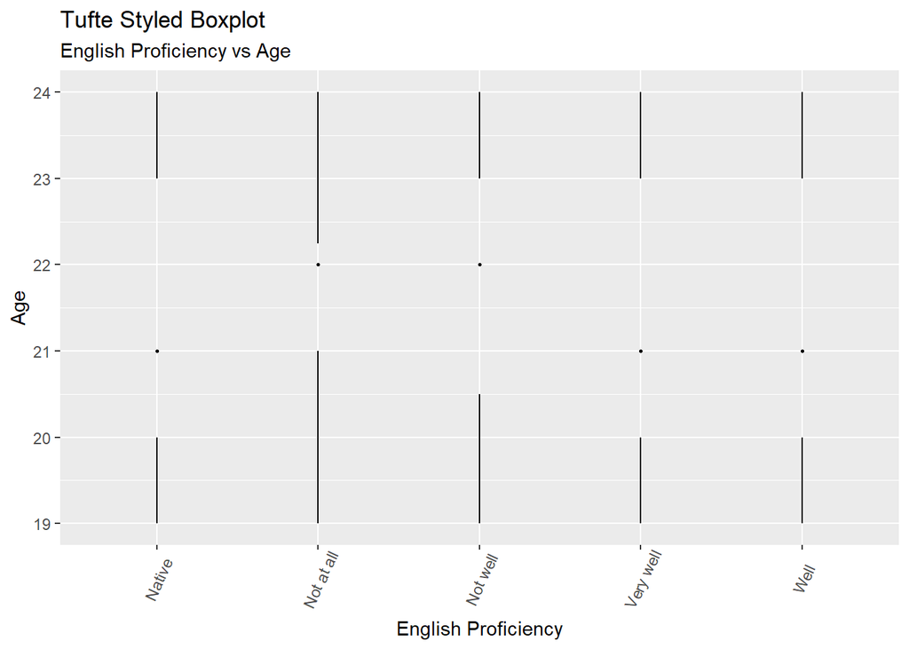

```r
library(ggthemes)
g <- ggplot(person_data, aes(ENG_label, AGEP))
g + geom_tufteboxplot() +
      theme(axis.text.x = element_text(angle=65, vjust=0.6)) +
      labs(title="Tufte Styled Boxplot",
           subtitle="English Proficiency vs Age",
           x="English Proficiency",
           y="Age")
```

```r
theme_set(theme_tufte())
```

#Plot 6

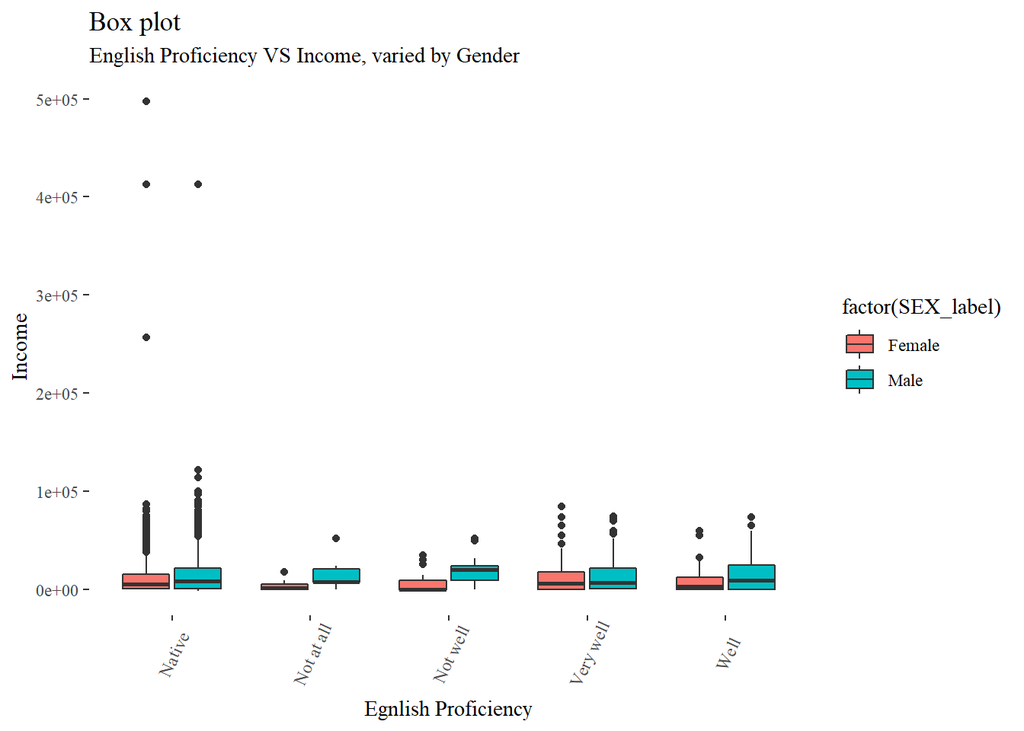

```r
df <- ggplot(person_data, aes(ENG_label, PINCP))
df + geom_boxplot(aes(fill=factor(SEX_label))) +
  theme(axis.text.x = element_text(angle=65, vjust=0.6)) +
  labs(title="Box plot",
       subtitle="English Proficiency VS Income, varied by Gender",
       x="Egnlish Proficiency",
       y="Income")
```

#Plot 7

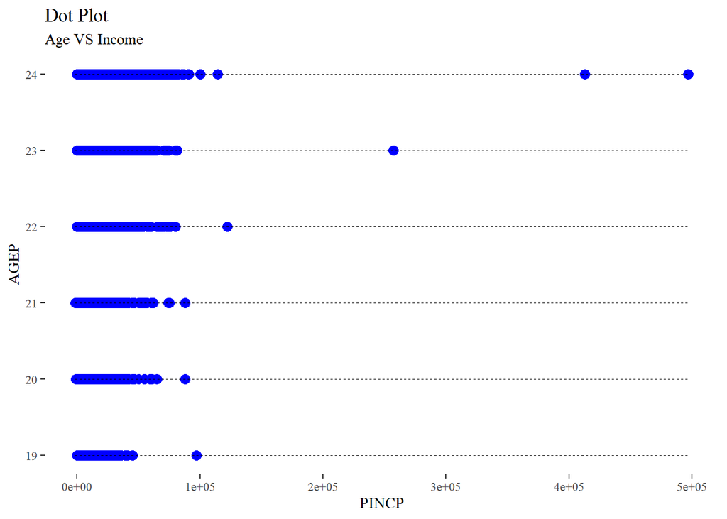

```r
ggplot(person_data, aes(x=AGEP, y=PINCP)) +
  geom_point(col="blue", size=3) +
  geom_segment(aes(x=AGEP,
                   xend=AGEP,
                   y=min(PINCP),
                   yend=max(PINCP)),
               linetype="dashed",
               size=0.1) +
  labs(title="Dot Plot",
       subtitle="Age VS Income") +
  coord_flip()
```

#Plot 8

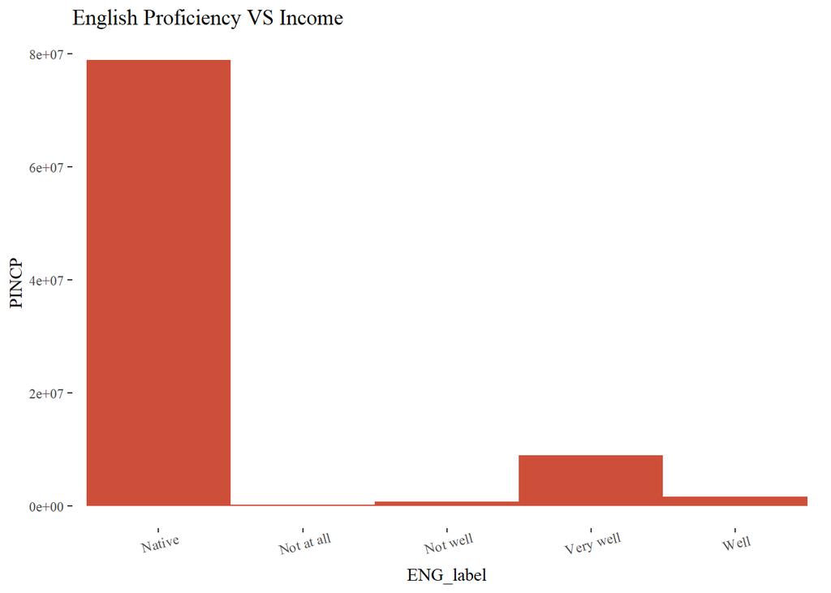

```r
ggplot(person_data, aes(x=ENG_label, y=PINCP)) +
  geom_bar(stat="identity", width=1, fill="tomato3") +
  labs(title="English Proficiency VS Income") +
  theme(axis.text.x = element_text(angle=15, vjust=0.9))
```

#Plot 9 ##I think the visual representation is very vibrant, but unfortunately it dones’t tell much about the data…

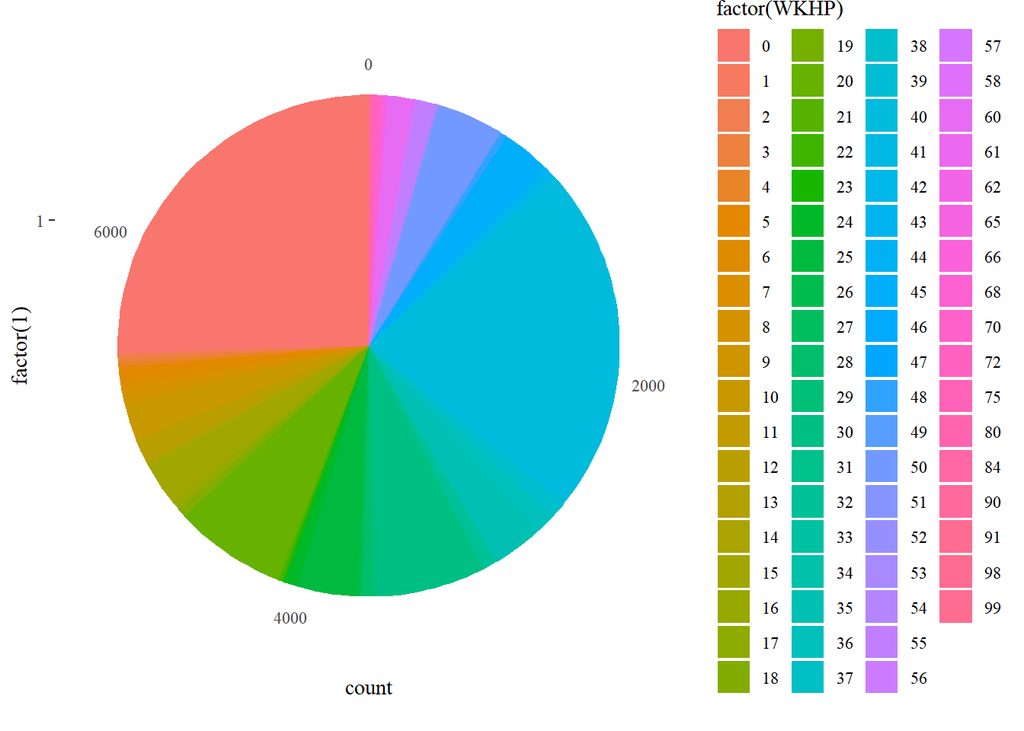

```r
coord_polar(theta = "x", start = 0, direction = 1, clip = "on")
pie <- ggplot(person_data,aes(x = factor(1), fill = factor(WKHP))) +
  geom_bar(width = 1)
pie + coord_polar(theta = "y")
```

#Plot 10 ##I don’t think this box plot represented the data well, because it is hard to tell the variation. I think if I limit the income between 0 to 60,000; then the differences should be more clear.

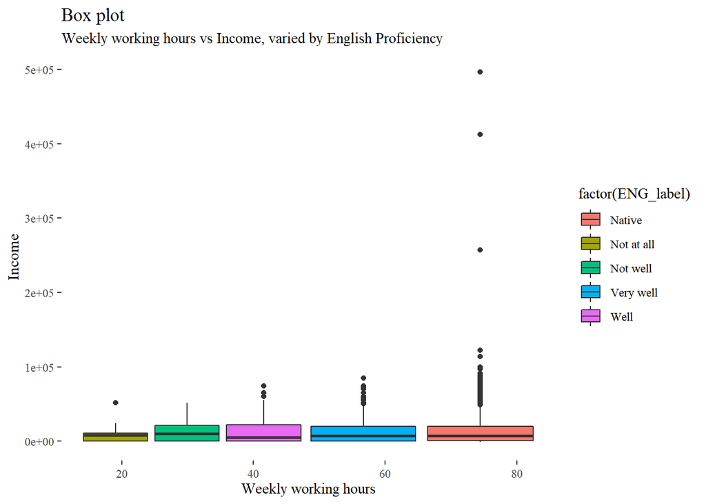

```r
df <- ggplot(person_data, aes(WKHP, PINCP))
df + geom_boxplot(aes(fill=factor(ENG_label))) +
  theme(axis.text.x = element_text(angle=0, vjust=0.6)) +
  labs(title="Box plot",
       subtitle="Weekly working hours vs Income, varied by English Proficiency",
       x="Weekly working hours",
       y="Income")
```

#Plot 10 Alternative 2

##I saw the heatmap example from TA Taelor and I liked the idea, and the visual presentation, though I think I need to twist the color a bit more to better represent the data.

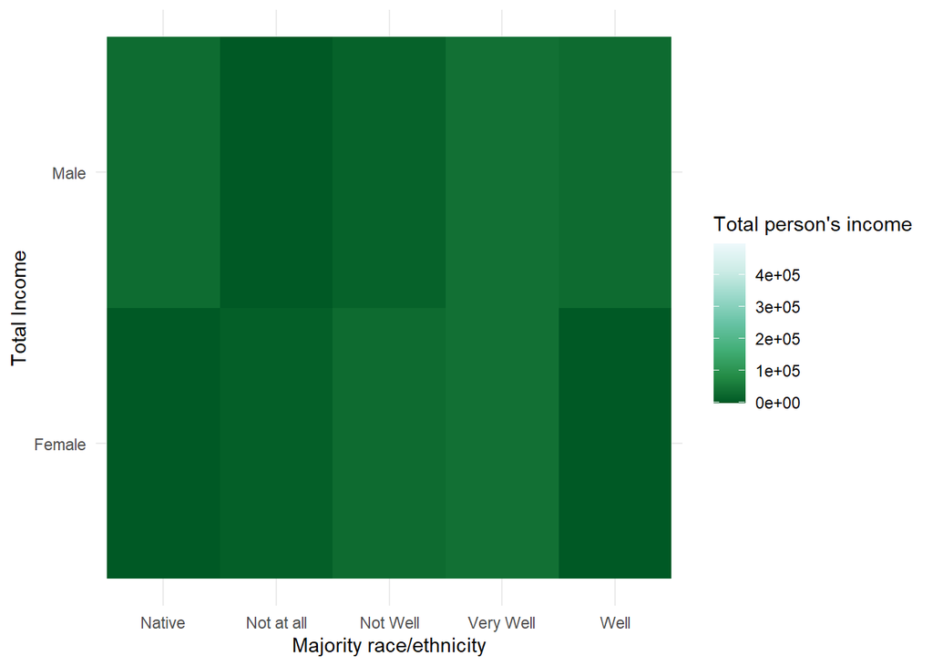

```r
ggplot(person_data, aes(x = ENG_label, y = SEX_label, fill = PINCP, scientific=FALSE)) +
       geom_tile() +
      scale_x_discrete(name = "Majority race/ethnicity",
                       labels = c("Native",
                                  "Not at all",
                                  "Not Well",
                                  "Very Well",
                                  "Well")) +
      scale_y_discrete(name = "Total Income") +
      scale_fill_distiller(palette = "BuGn") +
      labs(fill = "Total person's income") +
      theme_minimal()
```

#SUMMARY

##Unsure who will be reading this summary, but I would like to thank Taelor for being very patient with me. I have bothered her for about 10 times for all sorts of minor issues, but she never avoided me. I would also like to thank Aleks for helping me reviewing this assignment (when I truly feel bad asking Taelor again). I would like to thank Carole for your help as well, you have efficiently solved a few minor issues for me. I will keep working on R and keep “shamelessly” asking help from all of you. Hopefully by final week of this semester, I can honestly say that “I can work (a bit) in R!”.